# Thesis Work

Lauren Flynn

2022-11-03

#change from 500 to 5000 families # make a four column table, one for each level of the families, carrier risk,

## Functions to Generate Families

This first section uses the PedUtils package to generate simulated families. The only gene we are including is MLH1 and the only cancer we are including is colorectal cancer.

```r
#generate families
families = list()
probandIDS = c()
probandMLH1Status = c()
#outputs = c()
for (i in 1:10) {
  # Cancers
  cancers = "Colorectal"
  # Genes
  genes = "MLH1"
  #family members
  # Paternal aunts, paternal uncles
  nSibsPatern =floor(rtruncnorm(n=2, mean=3, 3))
  # Maternal aunts, maternal uncles
  nSibsMatern = floor(rtruncnorm(n=2, mean=3, 3))
  # Sisters and brothers
  nSibs = floor(rtruncnorm(n=2, mean=3, 3))
  # We make the assumption that the number of sons and daughters for the
  # proband and all siblings, is the same. Nieces and nephews of the proband
  # are not sampled separately.
  nGrandchild = floor(rtruncnorm(n=2, mean=6, 2))
  nChild = floor(rtruncnorm(n=2, mean=3, 2))

  # Simulate family using `PedUtils` code
  fam = sim.runSimFam(nSibsPatern, nSibsMatern, nSibs, nChild,
                      PanelPRODatabase, genes, cancers,
                      includeGeno = TRUE, includeBiomarkers = TRUE)
  famDF = as.data.frame(fam)
  proband = famDF %>% filter(isProband==1)
  probandIDS = c(probandIDS, proband$ID)
  probandMLH1Status = c(probandMLH1Status, proband$MLH1)
  # PanelPRO can be run on the simulated family
  #out = PanelPRO:::PanelPRO11(fam)
  families[[i]] = famDF
  #outputs = c(outputs, out)

}
```

## Remove MLH1 Status from Probands

Here we will create a function to remove the MLH1 status from the probands so that PanelPRO can predict the status. Additionally, there is a function to remove the relative status in order to get information that more accurately resembles the Ambry requistion information.

```r
removeProbandStatus <- function(ped){
  proband = ped %>% filter(isProband == 1)
  proband$MLH1 = NA
  relatives = ped %>% filter(isProband == 0)
  fam = rbind(proband, relatives)
  return(fam)
}

removeRelativeStatus <- function(ped){
  proband = ped %>% filter(isProband == 1)
  relatives = ped %>% filter(isProband == 0)
  relatives$MLH1 = NA
  fam = rbind(proband, relatives)
  return(fam)
}
```

Now we can apply the functions on the full families, saving the full families with MLH1 status into a separate variable.

```r
mlh1StatusFamilies <- families

for(i in 1:length(families)){
  families[[i]] <- removeProbandStatus(families[[i]])
  families[[i]] <- removeRelativeStatus(families[[i]])
}
```

## First Degree Families

Next we will filter down to the first degree families (proband, parents, siblings).

```r
firstDegreeFamilyMembers <- function(ped){
  proband <- ped %>% filter(isProband==1)
  firstDegree = proband
  if(!is.null(proband)){
    for(i in  1:nrow(ped)){
      relative=ped[i,]
      #siblings
      if(relative$ID != proband$ID){
        if(!is.null(relative$MotherID) && !is.null(proband$MotherID) && !is.null(relative$FatherID) && !is.null(proband$FatherID) && (relative$MotherID==proband$MotherID) && (relative$FatherID==proband$FatherID)){
          firstDegree <- rbind(firstDegree, relative)
        }
        #parents
        else if(!is.null(proband$MotherID) && !is.null(proband$FatherID) && (relative$ID == proband$MotherID || relative$ID == proband$FatherID)){
          firstDegree <-rbind(firstDegree,relative)
        }
      }
    }
  }
  return(firstDegree)
}
```

## Ambry Information

The Ambry requistion form has limited information about the proband, and very limited information about the proband’s family history. Sometimes the only information known about the proband and their family history is from this form or a similar form, so we will simulate the restrictive nature of this data collection for the proband and their relatives. While the ambry form contains a free text box to enter any relatives at all, we will use the function above to restrict to first degree families to ensure that we are able to draw all connections in the pedigree (for example if there is a cousin in the form that we don’t know their parents, we won’t know where to attach them).

```r
## Function to filter down to Ambry info ##
#### Proband info: sex, age, isDead==no, NA for riskMod and for interAge ###
ambryProbandInfo <- function(ped){
  proband = ped %>% filter(isProband==1)
  #proband$riskmod <- character(0)
  #proband$interAge <- character(0) #should these be character(0)? what does that mean?
  proband$isDead <- 0
  return(proband)
}

### relative info ###
#for simplicity, we will just say that sex can be inferred
#restricting to first degree family
#here genes is just MLH1
ambryRelativeInfo <- function(ped){
  relatives = ped %>% filter(isProband==0)
  #print(relatives)
  relatives$CurAge <- NULL
  relatives$isDead <- NULL
  #relatives$riskMod <- character(0)
  #relatives$interAge <- character(0)
  #View(relatives)
  return(relatives)
}
```

## Filter to Affected Family

Next we want to make a function that will filter to the affected family members in addition to the proband and their parents.

```r
#returns all affected family members and proband (affected or otherwise)
affectedFamilyMembers <- function(ped){
  proband <- ped %>% filter(isProband==1)
  mother <- ped %>% filter(ID == proband$MotherID)
  father <- ped %>% filter(ID == proband$FatherID)
  relatives <- ped %>% filter(isAffAny==1)
  relatives <- relatives %>% filter(isProband==0 && ID != proband$MotherID && ID != proband$FatherID) #to make sure we don't duplicate family members
  affectedFam <- rbind(proband, relatives, mother, father)
  return(affectedFam)
}
```

## Create Families

Using the many functions we have defined above, we can now take our full family pedigrees and generate limited pedigrees.

```r
#make first degree families
firstDegree = list()
for(i in 1:length(families)){
  firstDegree[[i]] = firstDegreeFamilyMembers(families[[i]])
}

#restrict to ambry information
ambryFirstDegree = list()
for(i in 1:length(firstDegree)){
  prob = ambryProbandInfo(firstDegree[[i]])
  rels = ambryRelativeInfo(firstDegree[[i]])
  famAm = rbind.fill(prob, rels)
  famAm = famAm %>% affectedFamilyMembers()
  print(nrow(famAm))
  ambryFirstDegree[[i]] = famAm
}
```

```
## [1] 3
## [1] 3
## [1] 3
## [1] 3
## [1] 3
## [1] 3
## [1] 3
## [1] 3
## [1] 3
## [1] 3
```

#### Family Variable Names and Descriptions

| Variable | Description |
| --- | --- |
| families | full families, including proband, parents, siblings, aunts, uncles, cousins, etc. generated with PedUtils |
| firstDegree | first degree families, starting with the full families and restricting to parents, siblings, and proband |
| ambryFirstDegree | first degree families with information restricted to what can be determined from Ambry requistion form |

## Descriptions of Families

```r
describeFamilies <- function(fams){
  affectedFamilies = 0
  affectedProbands = 0
  famSizes = c()
  mlh1Families = 0
  mlh1Probands = 0
  #affectedFamiliesList = list()
  #j = 1
  for(i in 1:length(fams)){
    f = fams[[i]]
    sizeOfFamily = nrow(f)
    famSizes = c(famSizes, sizeOfFamily)
    f = f %>% filter(isAffAny==1) %>% filter(isProband==0)
    if(nrow(f)>0){
      affectedFamilies = affectedFamilies + 1
      #affectedFamiliesList[[j]] = f
      #j = j + 1
    }
    mlh1fams = fams[[i]] %>% filter(isProband==0) %>% filter(MLH1==1)
    if(nrow(mlh1fams) > 0){
      mlh1Families = mlh1Families + 1
    }
    pb = fams[[i]] %>% filter(isProband==1)
    if(pb$isAffAny == 1){
      affectedProbands = affectedProbands + 1
    }
    if(!is.na(pb$MLH1)){
      if(pb$MLH1 == 1){
        mlh1Probands = mlh1Probands + 1
      }}
  }
  print(paste0("Number of families: ", length(fams)))
  print(paste0("Number of families with affected individuals: ", affectedFamilies))
  print(paste0("Number of families with affected probands: ", affectedProbands))
  print(paste0("Average family size: ", mean(famSizes)))
  print("Summary of family sizes")
  print(summary(famSizes))
  print(paste0("Number of probands that with MLH1 gene: ", mlh1Probands))
  print(paste0("Number of families (non-proband) with MLH1 gene: ", mlh1Families))
}
```

#### Full Family

Considering MLH1 Status:

```r
#changing considered families allows us to make this function more reusable
considered_fams = mlh1StatusFamilies
print("Full Families from PedUtils")
```

```
## [1] "Full Families from PedUtils"
```

```r
describeFamilies(considered_fams)
```

```
## [1] "Number of families: 10"
## [1] "Number of families with affected individuals: 5"
## [1] "Number of families with affected probands: 0"
## [1] "Average family size: 78.7"
## [1] "Summary of family sizes"
##    Min. 1st Qu.  Median    Mean 3rd Qu.    Max.
##    75.0    75.0    76.0    78.7    81.0    91.0
## [1] "Number of probands that with MLH1 gene: 1"
## [1] "Number of families (non-proband) with MLH1 gene: 1"
```

Removed MLH1 Status:

```r
#changing considered families allows us to make this function more reusable
considered_fams = families
print("Full Families from PedUtils")
```

```
## [1] "Full Families from PedUtils"
```

```r
describeFamilies(considered_fams)
```

```
## [1] "Number of families: 10"
## [1] "Number of families with affected individuals: 5"
## [1] "Number of families with affected probands: 0"
## [1] "Average family size: 78.7"
## [1] "Summary of family sizes"
##    Min. 1st Qu.  Median    Mean 3rd Qu.    Max.
##    75.0    75.0    76.0    78.7    81.0    91.0
## [1] "Number of probands that with MLH1 gene: 0"
## [1] "Number of families (non-proband) with MLH1 gene: 0"
```

#### First Degree Families

```r
considered_fams = firstDegree
print("First Degree Families")
```

```
## [1] "First Degree Families"
```

```r
describeFamilies(considered_fams)
```

```
## [1] "Number of families: 10"
## [1] "Number of families with affected individuals: 1"
## [1] "Number of families with affected probands: 0"
## [1] "Average family size: 9.8"
## [1] "Summary of family sizes"
##    Min. 1st Qu.  Median    Mean 3rd Qu.    Max.
##     9.0    10.0    10.0     9.8    10.0    10.0
## [1] "Number of probands that with MLH1 gene: 0"
## [1] "Number of families (non-proband) with MLH1 gene: 0"
```

#### First Degree Families Restricted Information

```r
considered_fams = ambryFirstDegree
print("First Degree Families with Restricted Ambry Information")
```

```
## [1] "First Degree Families with Restricted Ambry Information"
```

```r
describeFamilies(considered_fams)
```

```
## [1] "Number of families: 10"
## [1] "Number of families with affected individuals: 1"
## [1] "Number of families with affected probands: 0"
## [1] "Average family size: 3"
## [1] "Summary of family sizes"
##    Min. 1st Qu.  Median    Mean 3rd Qu.    Max.
##       3       3       3       3       3       3
## [1] "Number of probands that with MLH1 gene: 0"
## [1] "Number of families (non-proband) with MLH1 gene: 0"
```

Below we have the function to count how many affected family members there are in each family. 0 means that the family members are all unaffected, 1 means one family member is affected, etc.

```r
affectedFamiliesLister <- function(f){
  affectedFamiliesList = list()
  for(i in 1:length(families)){
    fam = as.data.frame(f[[i]])
    fam = fam %>% filter(isAffAny==1) %>% filter(isProband==0)
      if(nrow(fam) > 0){
        affectedFamiliesList[[i]] = nrow(fam)
      }
      else{
        affectedFamiliesList[[i]] = 0}
    }
  return(affectedFamiliesList)
}
```

Now we can apply it to each of our families

```r
considered_fams = mlh1StatusFamilies
print("Full Families from PedUtils with MLH1 status")
```

```
## [1] "Full Families from PedUtils with MLH1 status"
```

```r
print(unlist(affectedFamiliesLister(considered_fams)))
```

```
##  [1] 1 1 0 0 0 0 2 1 0 2
```

```r
#this should be the same as above but just want to check to make sure
considered_fams = families #no mlh1 status (should be the same as above)
print("Full Families from PedUtils")
```

```
## [1] "Full Families from PedUtils"
```

```r
print(unlist(affectedFamiliesLister(considered_fams)))
```

```
##  [1] 1 1 0 0 0 0 2 1 0 2
```

```r
#this should be less than or equal to above
considered_fams = firstDegree
print("First Degree Families")
```

```
## [1] "First Degree Families"
```

```r
print(unlist(affectedFamiliesLister(considered_fams)))
```

```
##  [1] 0 0 0 0 0 0 1 0 0 0
```

```r
# #this should also be the same as first degree families above but will provide us a check
considered_fams = ambryFirstDegree
print("First Degree Families with Restricted Ambry Information")
```

```
## [1] "First Degree Families with Restricted Ambry Information"
```

```r
print(unlist(affectedFamiliesLister(considered_fams)))
```

```
##  [1] 0 0 0 0 0 0 1 0 0 0
```

## Generating PanelPRO Output

```r
# #for full families
outputsFull <- list ()
fullCarrierRisk <- list()
considered_fams = families
for(i in 1:length(families)){
  out = PanelPRO::PanelPRO(families[[i]], genes="MLH1", cancers="Colorectal")
  id = as.character(probandIDS[i])
  fullCarrierRisk[[i]] <- out$posterior.prob[[id]]$estimate[2]
  outputsFull[[i]] = out#DF
}
```

[output not shown]

[output not shown]

[output not shown]

[output not shown]

[output not shown]

[output not shown]

[output not shown]

[output not shown]

[output not shown]

[output not shown]

```
## Germline testing results for MLH1 are assumed to be for default variant
## MLH1_hetero_anyPV.
```

```r
#
# #for first degree families
outputsFirstDegree <- list ()
firstDegreeCarrierRisk <- list()
considered_fams = firstDegree
for(i in 1:length(families)){
  out = PanelPRO::PanelPRO(firstDegree[[i]], genes="MLH1", cancers="Colorectal")
  id = as.character(probandIDS[i])
  firstDegreeCarrierRisk[[i]] <- out$posterior.prob[[id]]$estimate[2]
  outputsFirstDegree[[i]] = out#DF
}
```

```
## Your model has 1 cancers - Colorectal and 1 genes - MLH1_hetero_anyPV.
## Setting max.mut to 1.
## ID 23,6,12,20,21,22,24,25,26,27 is unaffected for COL, forcing affection age to NA.
```

```
## Germline testing results for MLH1 are assumed to be for default variant MLH1_hetero_anyPV.
## Your model has 1 cancers - Colorectal and 1 genes - MLH1_hetero_anyPV.
## Setting max.mut to 1.
## ID 20,6,12,21,22,23,24,25,26,27 is unaffected for COL, forcing affection age to NA.
```

```
## Germline testing results for MLH1 are assumed to be for default variant MLH1_hetero_anyPV.
## Your model has 1 cancers - Colorectal and 1 genes - MLH1_hetero_anyPV.
## Setting max.mut to 1.
## ID 20,6,13,21,22,23,24,25,26,27 is unaffected for COL, forcing affection age to NA.
```

```
## Germline testing results for MLH1 are assumed to be for default variant MLH1_hetero_anyPV.
## Your model has 1 cancers - Colorectal and 1 genes - MLH1_hetero_anyPV.
## Setting max.mut to 1.
## ID 21,7,13,22,23,24,25,26,27 is unaffected for COL, forcing affection age to NA.
```

```
## Germline testing results for MLH1 are assumed to be for default variant MLH1_hetero_anyPV.
## Your model has 1 cancers - Colorectal and 1 genes - MLH1_hetero_anyPV.
## Setting max.mut to 1.
## ID 22,6,12,19,20,21,23,24,25,26 is unaffected for COL, forcing affection age to NA.
```

```
## Germline testing results for MLH1 are assumed to be for default variant MLH1_hetero_anyPV.
## Your model has 1 cancers - Colorectal and 1 genes - MLH1_hetero_anyPV.
## Setting max.mut to 1.
## ID 26,6,12,23,24,25,27,28,29,30 is unaffected for COL, forcing affection age to NA.
```

```
## Germline testing results for MLH1 are assumed to be for default variant MLH1_hetero_anyPV.
## Your model has 1 cancers - Colorectal and 1 genes - MLH1_hetero_anyPV.
## Setting max.mut to 1.
## ID 20,6,21,22,23,24,25,26,27 is unaffected for COL, forcing affection age to NA.
```

```
## Germline testing results for MLH1 are assumed to be for default variant MLH1_hetero_anyPV.
## Your model has 1 cancers - Colorectal and 1 genes - MLH1_hetero_anyPV.
## Setting max.mut to 1.
## ID 21,6,13,22,23,24,25,26,27 is unaffected for COL, forcing affection age to NA.
```

```
## Germline testing results for MLH1 are assumed to be for default variant MLH1_hetero_anyPV.
## Your model has 1 cancers - Colorectal and 1 genes - MLH1_hetero_anyPV.
## Setting max.mut to 1.
## ID 20,6,12,21,22,23,24,25,26,27 is unaffected for COL, forcing affection age to NA.
```

```
## Germline testing results for MLH1 are assumed to be for default variant MLH1_hetero_anyPV.
## Your model has 1 cancers - Colorectal and 1 genes - MLH1_hetero_anyPV.
## Setting max.mut to 1.
## ID 25,6,12,21,22,23,24,26,27,28 is unaffected for COL, forcing affection age to NA.
```

```
## Germline testing results for MLH1 are assumed to be for default variant
## MLH1_hetero_anyPV.
```

```r
#
#
# #for first degree ambry families
# outputsFirstDegreeAmbry <- list ()
# firstDegreeAmbryCarrierRisk <- list()
# for(i in 1:length(families)){
#   out = PanelPRO::PanelPRO(ambryFirstDegree[[i]], genes="MLH1", cancers="Colorectal")
#   id = as.character(probandIDS[i])
#   firstDegreeAmbryCarrierRisk[[i]] <- out$posterior.prob[[id]]$estimate[2]
#   outputsFirstDegreeAmbry[[i]] = out#DF
# }
```

The code to get the outputs for the ambry information first degree families is not working because of the following family:

```r
ambryFirstDegree[[1]]
```

```
##   ID Sex MotherID FatherID isProband CurAge isAffCOL isAffAny AgeCOL AgeAny
## 1 23   1       12        6         1     33        0        0     33     33
## 2 12   0       10       11         0     NA        0        0     60     60
## 3  6   1        1        2         0     NA        0        0     73     73
##   isDead Twins Ancestry      race riskmod interAge MLH1
## 1      0     0    nonAJ All_Races                    NA
## 2     NA     0    nonAJ All_Races                    NA
## 3     NA     0    nonAJ All_Races                    NA
```

```r
#out = PanelPRO::PanelPRO(ambryFirstDegree[[1]], genes="MLH1", cancers="Colorectal")
```

and we get the following error message:

Above we have put the PanelPRO outputs:

[output not shown]

## Table

```r
mlh1ProbandsTotal <- c()
probandMLH1 <- list()
for(i in 1:length(families)){
  if(nrow(mlh1StatusFamilies[[i]] %>% filter(MLH1 ==1) %>% filter(isProband==1) > 0)){
    mlh1ProbandsTotal <- c(mlh1ProbandsTotal, i)
    probandMLH1[[i]] = 1
   }
  else{
    probandMLH1[[i]] = 0
  }}

summaryTableMLH1 <- cbind(unlist(fullCarrierRisk), unlist(firstDegreeCarrierRisk), unlist(affectedFamiliesLister(families)), unlist(affectedFamiliesLister(firstDegree)), unlist(probandMLH1))

summaryTableMLH1 <- as.data.frame(summaryTableMLH1)

names(summaryTableMLH1) <- c("Carrier Risk for Full Families", "Carrier Risk for First Degree Families", "Affected Individuals Full Familes", "Affected Individuals First Degree Families", "True MLH1 Carriers")

print(summaryTableMLH1)
```

```
##    Carrier Risk for Full Families Carrier Risk for First Degree Families
## 1                    1.930159e-04                           0.0004070911
## 2                    1.462201e-03                           0.0004643406
## 3                    6.368669e-05                           0.0004663435
## 4                    5.946615e-05                           0.0004802265
## 5                    7.851172e-05                           0.0004961206
## 6                    3.077810e-05                           0.0003402842
## 7                    3.914199e-04                           0.0019530430
## 8                    4.019039e-04                           0.0003975618
## 9                    5.788589e-05                           0.0004768054
## 10                   9.559704e-05                           0.0001508233
##    Affected Individuals Full Familes Affected Individuals First Degree Families
## 1                                  1                                          0
## 2                                  1                                          0
## 3                                  0                                          0
```

[output cut: 18 more lines]

## Graphs

```r
fullRisk <- unlist(fullCarrierRisk)
summary(fullRisk)
```

```
##      Min.   1st Qu.    Median      Mean   3rd Qu.      Max.
## 3.078e-05 6.052e-05 8.705e-05 2.834e-04 3.418e-04 1.462e-03
```

```r
fullRisk #here the highest carrier risk corresponds with the actual carrier
```

```
##  [1] 1.930159e-04 1.462201e-03 6.368669e-05 5.946615e-05 7.851172e-05
##  [6] 3.077810e-05 3.914199e-04 4.019039e-04 5.788589e-05 9.559704e-05
```

```r
firstDegreeRisk <- unlist(firstDegreeCarrierRisk)
summary(firstDegreeRisk)
```

```
##      Min.   1st Qu.    Median      Mean   3rd Qu.      Max.
## 0.0001508 0.0003999 0.0004653 0.0005633 0.0004794 0.0019530
```

```r
firstDegreeRisk #here it does not
```

```
##  [1] 0.0004070911 0.0004643406 0.0004663435 0.0004802265 0.0004961206
##  [6] 0.0003402842 0.0019530430 0.0003975618 0.0004768054 0.0001508233
```

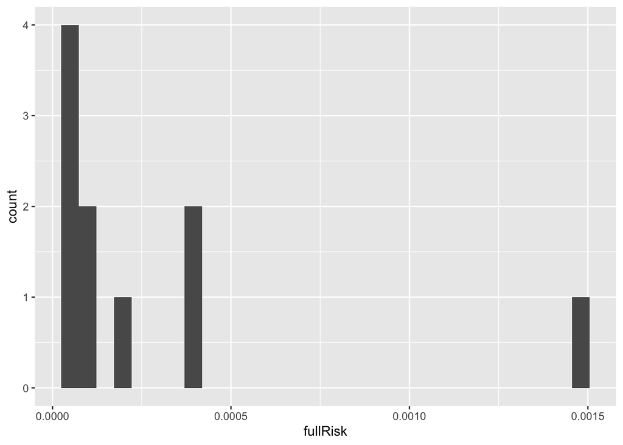

```r
mlh1FamiliesTotal <- c()
actualMLH1 <- list()
for(i in 1:length(families)){
  if(nrow(mlh1StatusFamilies[[i]] %>% filter(MLH1 ==1)) > 0){
  mlh1FamiliesTotal <- c(mlh1FamiliesTotal, i)
  actualMLH1[[i]] = 1}
  else{
    actualMLH1[[i]] = 0}
}


ggplot(data= as.data.frame(fullRisk)) + geom_histogram(aes(x=fullRisk))
```

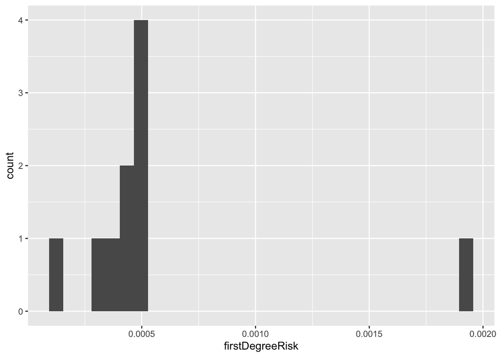

```r
ggplot(data= as.data.frame(firstDegreeRisk)) + geom_histogram(aes(x=firstDegreeRisk))
```

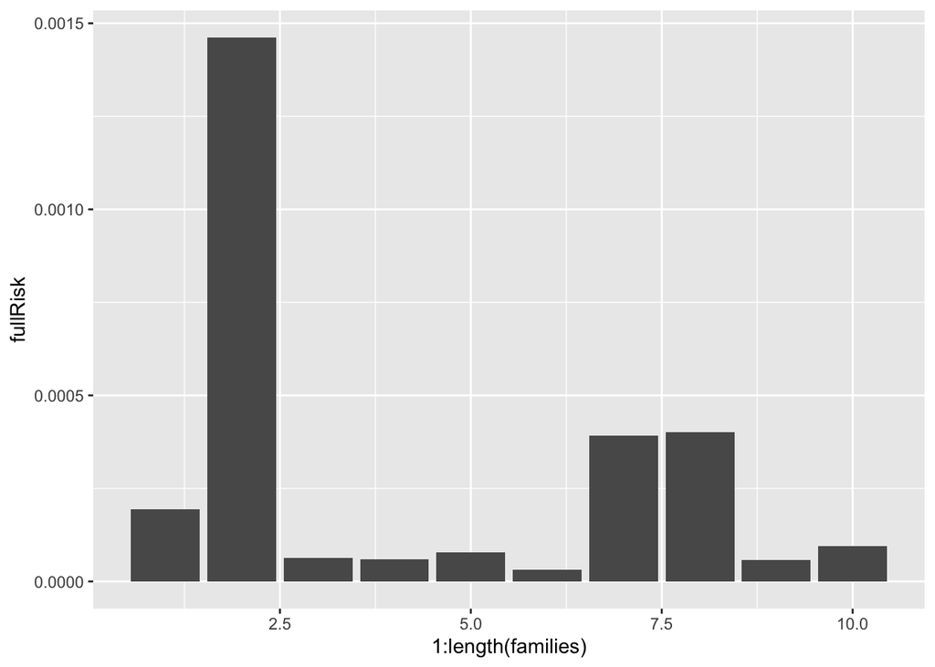

```r
ggplot(data= as.data.frame(fullRisk)) + geom_col(aes(x=1:length(families), y = fullRisk))
```

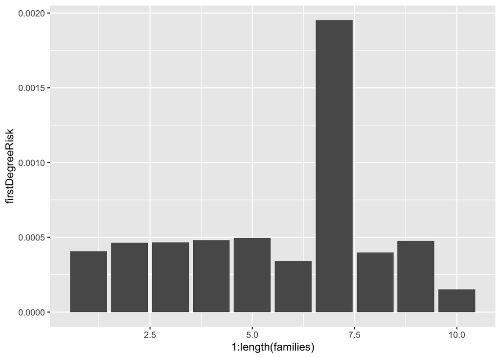

```r
ggplot(data= as.data.frame(firstDegreeRisk)) + geom_col(aes(x=1:length(families), y = firstDegreeRisk))
```

```r
summaryTableMLH1 <- summaryTableMLH1 %>% mutate("famID" = 1:length(families))

#facet_grid(
```